# R Markdown

Devin Judge-Lord

02 February, 2019

***This is why don’t copy and paste numbers, table, or figures into a paper.**

## R Markdown

Markdown is just **plain text** that can be rendered as HTML, PDF, or even Microsoft Word. Rstudio’s “Knit” button will make the selected document.

We can use various syntaxes, like $\LaTeX$ and **R** as needed inline with the rest of our text, which we write in [markdown syntax](https://bookdown.org/yihui/rmarkdown/markdown-syntax.html). For example, typing “$`y = \alpha + X\beta`$” gives us “$y = \alpha + X\beta$” and typing “{`r` `nchar("hello world")`}” gives us “11”—pretty cool. For more, see http://rmarkdown.rstudio.com, especially this [cheatsheet](http://rmarkdown.rstudio.com).

We can embed a chunk of R code like this:

```r
# a dataset built into R
head(pressure)
```

```
##   temperature pressure
## 1           0   0.0002
## 2          20   0.0012
## 3          40   0.0060
## 4          60   0.0300
## 5          80   0.0900
## 6         100   0.2700
```

In [the .Rmd file](https://github.com/judgelord/PS811/blob/master/2-RMarkdown.Rmd), you’ll see that the above chunk of R code begins with “```{r pressure}”, which tells the computer that this chunk is `r` code and names this chunk “pressure.”

Give code chunks informative names! If your chunk produces figures, they will be saved with this name.

If we don’t want our code chunk in the output, only the results, we add `echo = FALSE` to the header:

```
##   temperature pressure
## 1           0   0.0002
## 2          20   0.0012
## 3          40   0.0060
## 4          60   0.0300
## 5          80   0.0900
## 6         100   0.2700
```

We can set defaults for the whole document (e.g. `knitr::opts_chunk$set(echo = TRUE)`). See the above “setup” chunk in this .Rmd file.

Problem sets and papers will use `echo = FALSE` to display just the output. For notes, we may want to see our code `echo = TRUE`. Or, if our output is HTML, hide our code; try knitting to HTML after adding `code_folding: hide` to the YAML header in this .Rmd file like this:

```
  html_document:
      latex_engine: pdflatex
      code_folding: hide
```

To display code we don’t want to run, we add `eval = FALSE`.

```r
This code will not run.
```

For example, if you want to share code that does not work on your 811 page, use `eval = FALSE`.

It is safer to use `cache = FALSE`, which re-computes all results each time and will thus update if your data have changed. If computing is taking a long time, you can use `cache = TRUE` to knit faster, but this will only run chunks where the *code* has changed.

## Including Plots

We can also embed plots. For example:

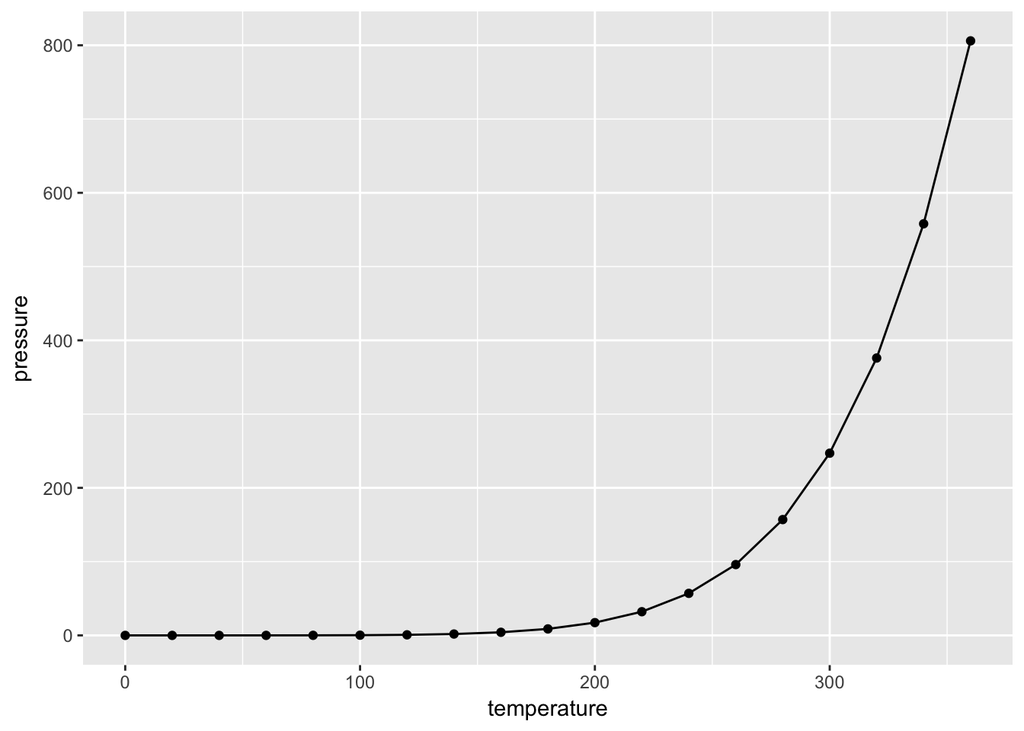

```r
library(ggplot2);
ggplot(data = pressure, aes(x = temperature, y = pressure)) +
  geom_point() +
  geom_line()
```

Note that we needed to load the library `ggplot2` because knitting uses a new **R** session. Your .Rmd file must load any required libraries, functions, and data. The upshot of this is that knitting is self-contained. It starts fresh; not depending on whatever you may have done in **R** previously.

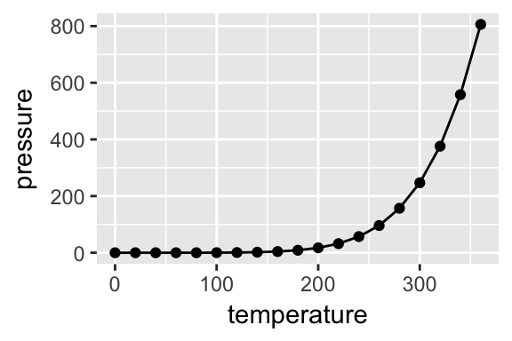

Let us also center `fig.align='center` and add a caption, `fig.cap = "Plotting Temperature vs. Pressure"`:

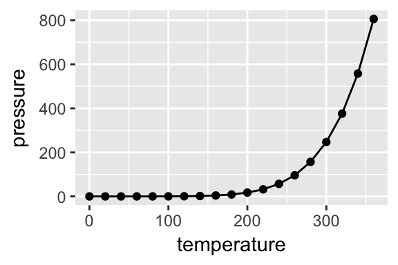

Plotting Temperature vs. Pressure

# Two ways to code

#### 1. Get code working in a .R file (e.g. in your /scratchpad subfolder), then copy the final code into .Rmd file chunks.

#### 2. Workshop code in .Rmd file chunks.

#### You may want to change RStudio settings (gear button) to `Chunk Output in Consol`

Either way, press command/control+enter to run **a line or highlighted section** locally. If using a remote server, command/control+option/alt+enter will send it to the terminal/bash.

# Writing Math

We can use MathJax and/or $\LaTeX$ to write nice-looking math. For example, we can write out a regression equation as $y = \alpha + X\beta + \varepsilon$, without having to copy, paste, or insert special symbols. To write out anything math related, we enclose it in dollar signs $\$$`math`$\$$. The regression equasion above, for example, is $\$$ `y = \alpha + X\beta + \varepsilon` $\$$. If we want to index something by adding subscripts $x_{1}, x_{2}$ etc, the code is $\$$`x_{1}, x_{2}`$\$$. Fractions are written such that $\$$`\frac{1}{2}`$\$$ is $\frac{1}{2}$, and exponents ($2^{2}$) are written $\$$`2^{2}`$\$$.

The Greek letters have a slash before them which tells $\LaTeX$ or MathJax to print that as a Greek letter. Similarly $2 \times 2$ is written $\$$ `2 \times 2` $\$$. See guides to special characters and formatting in $\LaTeX$ [here](https://users.dickinson.edu/~richesod/latex/latexcheatsheet.pdf) and MathJax [here](https://math.meta.stackexchange.com/questions/5020/mathjax-basic-tutorial-and-quick-reference). I regularly google symbols.

## Matrices

To write a matrix:
$$\left[
\begin{array}{ccc}
1 & 2 & 3 \\
4 & 5 & 6\\
7 & 8 & 0
\end{array}
\right]$$
we write:

```r
$$
\left[
\begin{array}{ccc}
1 & 2 & 3 \\
4 & 5 & 6\\
7 & 8 & 0
\end{array}
\right]
$$
```

where:

```r
$$ % start Latex mode
\left[ %creates the left bracket, the "\left" command scales the bracket "["
\begin{array}{ccc} % Creates the "array" (matrix), {ccc} defines the number of columns
1 & 2 & 3 \\ % "&" divides the columns, "\\" creates a new line
4 & 5 & 6\\
7 & 8 & 0
\end{array} % ends the matrix
\right] %creates the left bracket, the "\right" command scales the bracket "]"
$$ % ends LaTeX mode
```

### Matrix multiplication

$$\left[
\begin{array}{ccc}
1 & 1 & 1
\end{array}
\right]
\times
\left[
\begin{array}{ccc}
1 & 2 & 3 \\
4 & 5 & 6\\
7 & 8 & 0
\end{array}
\right]
=
\left[
\begin{array}{ccc}
1 + 4 + 7 & 2 + 5 + 8 & 3 + 6 + 0
\end{array}
\right]
=
\left[
\begin{array}{ccc}
12 & 15 & 9
\end{array}
\right]$$

# Example Notes

### Linear regression with fixed effects:

$$y_{i} = \alpha_{0} + \alpha_{j} + x_{i} \beta + \varepsilon$$
Where $\alpha_{0}$ is the intercept,

$\alpha_{j}$ are fixed effects (effects that do not vary by $x$, i.e. intercept shifts) for each group $j$,

$x$ and $y$ are vectors of observations, and

$\varepsilon$ is the error.

### OLS estimation

Data:
$$X =
\left[
\begin{array}{cc}
x_{1, 1} & x_{1, 2} \\
x_{2, 1} & x_{2, 2} \\
\end{array}
\right],
\\
y =
\left[
\begin{array}{cc}
y_{1}\\
y_{2}\\
\end{array}
\right]$$

OLS equation
$$\hat{\beta} = (X'X)^{-1}(X'y)$$

### Logistic link function:

$$Pr(y_{i} = 1) = \frac{1}{1 + e^{-x_{i} \beta}}$$

### Poisson PMF:

$$\frac{\lambda^k}{k!} e^{-\lambda}$$

### Gaussian (normal) PDF:

$$\frac{1}{\sigma\sqrt{2\pi}}\, e^{-\frac{(x - \mu)^2}{2 \sigma^2}}$$